# Laboratorio 1.1: Exploración y Visualización de Datos

Andrés Calderón, Franco González

Agosto 2023

# Declaración de compromiso ético

Nosotros Andrés Calderón y Franco González, declaramos que realizamos de manera grupal los pasos de la presente actividad. También declaramos no incurrir en copia, ni compartir nuestras respuestas con otras personas ni con otros grupos. Por lo que, ratificamos que las respuestas son de nuestra propia confección y reflejan nuestro propio conocimiento.

# Instrucciones

1. Trabajen en equipos de dos personas. Salvo excepciones, no se corregirá entregas con menos de dos integrantes.
2. Modifique este archivo `.Rmd` agregando sus respuestas donde corresponda. Puede ocupar R-Studio en su computador o usar esta alternativa cloud “https://posit.cloud”.
3. Para cada pregunta **incluya el código fuente que utilizó para llegar a su respuesta. Respuestas sin código no recibirán puntaje.**.
4. El formato de entrega para esta actividad es un archivo html. **Genere un archivo HTML usando RStudio** y súbalo a U-Cursos.

Basta con que uno de los integrantes haga la entrega. Si ambos hacen una entrega en U-Cursos, se revisará cualquiera de éstas.

# Laboratorio

Ahora vamos a jugar con los datos!

En este laboratorio trabajaremos con un dataset del tema favorito de todxs… el anime. El dataset fue obtenido de “https://www.kaggle.com/datasets/azathoth42/myanimelist” y consta de informacion sobre animes de la pagina MyAnimeList (MAL)

Este set de datos consiste de dos archivos. “anime.csv” contiene 6 atributos: “title”, “type”, “source”, “episodes”, “airing” y “studio”, que corresponden a informacion sobre el anime, y “anime-stats.csv” contiene 4 atributos: “title”, “score”, “members” (numero de usuarios que tienen el anime en su lista) y “favorites”, que corresponden a estadisticas en MyAnimeList sobre la popularidad de animes.

Para cargar los datos desde tu computador, usa:

```r
df_anime <- read.csv("anime.csv", encoding="UTF-8")
df_stats <- read.csv("anime-stats.csv", encoding="UTF-8")
```

También puedes cargarlos remotamente de un repositorio usando el link a los archivos:

```r
df_anime <- read.csv("https://raw.githubusercontent.com/bacchus00/cositas/main/anime.csv", encoding="UTF-8")
df_stats <- read.csv("https://raw.githubusercontent.com/bacchus00/cositas/main/anime-stats.csv", encoding="UTF-8")
```

Reemplazaremos los string vacios por NAs (nulos) ya que corresponden a valores faltantes.

```r
df_anime = replace(df_anime, df_anime=='', NA)
df_stats = replace(df_stats, df_stats=='', NA)
```

### Exploración básica

1. ¿Cuáles son las dimensiones de ambos dataframes (filas, columnas)?

```r
dim(df_anime)
```

```
## [1] 14478     6
```

```r
dim(df_stats)
```

```
## [1] 14478     4
```

2. ¿Existen registros duplicados en alguno de los dataframes?

```r
sum(duplicated(df_anime))
```

```
## [1] 0
```

```r
sum(duplicated(df_stats))
```

```
## [1] 0
```

3. ¿Hay filas con valores nulos en alguno de los dataframes?

```r
sum(is.na(df_anime))
```

```
## [1] 5934
```

```r
sum(is.na(df_stats))
```

```
## [1] 0
```

### Análisis

Ahora para hacer el análisis más sencillo juntaremos ambas tablas usando como llave el nombre del anime (title).

```r
df <- merge(df_anime, df_stats, by.x = "title", by.y = "title")
```

1. Lista los animes que tienen una cantidad de episodios igual o mayor a 1000.

```r
head(df[df$episodes >= 1000, ])
```

```
##                                      title type   source episodes airing
## 2666                       Doraemon (1979)   TV    Manga     1787  False
## 4927                      Hoka Hoka Kazoku   TV  Unknown     1428  False
## 6498              Kirin Ashita no Calendar   TV  Unknown     1306  False
## 6500                Kirin Monoshiri Yakata   TV  Unknown     1565  False
## 7774    Manga Nippon Mukashibanashi (1976)   TV  Unknown     1471  False
## 8428 Monoshiri Daigaku: Ashita no Calendar   TV Original     1274  False
##                 studio score members favorites
## 2666 Shin-Ei Animation  7.73   20129       219
## 4927             Eiken  5.93     295         0
## 6498              <NA>  6.05     146         0
## 6500              <NA>  5.98     198         1
## 7774         Group TAC  6.37     619         2
## 8428              <NA>  6.42     211         0
```

2. Encuentra los 5 animes con mas favoritos según el dataset. ¿Te hace sentido que estos sean los animes con mas favoritos?

Sí, son bastante famosos.

```r
head(df[order(df$favorites, decreasing = TRUE), ], 5)
```

```
##                                  title type       source episodes airing
## 3365  Fullmetal Alchemist: Brotherhood   TV        Manga       64  False
## 12044                      Steins;Gate   TV Visual novel       24  False
## 2377                        Death Note   TV        Manga       37  False
## 9362                         One Piece   TV        Manga        0   True
## 5073            Hunter x Hunter (2011)   TV        Manga      148  False
##               studio score members favorites
## 3365           Bones  9.25 1199091    106895
## 12044      White Fox  9.14 1010330     92423
## 2377        Madhouse  8.67 1456378     88696
## 9362  Toei Animation  8.54  720133     69760
## 5073        Madhouse  9.11  720920     64375
```

3. Lista todos los studios (sin repetirse y sin incluir nulos) que tienen animes en entre los 20 con mejor score.

```r
df_no_null <- df[!is.na(df$studio), ]
df_score <- df_no_null[order(df_no_null$score, decreasing = TRUE), ]
df_3 <- head(unique(df_score$studio), 20)
df_3
```

```
##  [1] "Collaboration Works"   "Bones"                 "CoMix Wave Films"
##  [4] "Bandai Namco Pictures" "White Fox"             "Artland"
##  [7] "Sunrise"               "Madhouse"              "Shaft"
## [10] "Kyoto Animation"       "Production I.G"        "Studio Ghibli"
## [13] "Kinema Citrus"         "A-1 Pictures"          "Studio Deen"
## [16] "Studio Chizu"          "Studio Pierrot"        "Shuka"
## [19] "Gainax"                "Brain&#039;s Base"
```

4. ¿Hay algún studio que tenga más de un anime entre los 20 con mejor score? (sin repeticiones y si incluir nulos)

```r
df_20 <- head(df_score, 20)
unique(df_20[duplicated(df_20$studio), ]$studio)
```

```
## [1] "White Fox"             "Sunrise"               "Bandai Namco Pictures"
## [4] "Shaft"                 "Kyoto Animation"
```

5. Veamos cómo se distribuyen los scores de los anime. Para esto genere un histograma y agregue un título y etiquetas necesarias para que la visualización se entienda por sí misma. ¿Que tipo de distibucion parace ser? ¿Entre qué valores se concentran la mayor cantidad de streams? ¿Qué puedes decir de la presencia de outliers?

Es una distribución normal pues tiene aproximadamente una forma de campana de Gauss, la mayoría de datos se concentran entre un score de 4 y 8, y respecto a los outliers se puede observar que hay una alta frecuencia en los que califican con 0.

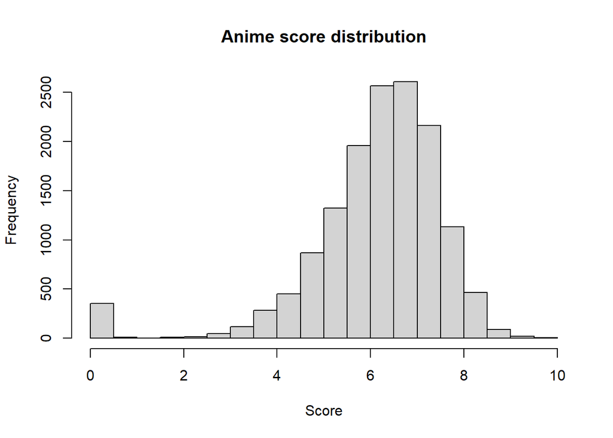

```r
hist(df$score, xlab=c('Score'), ylab=c('Frequency'), main=c('Anime score distribution'))
```

6. Ahora veamos con que es lo que se relaciona más los scores del anime. Para esto elige dos atributos numericos del dataset que creas influye en el score y crea un gráfico para ver como cada uno se relaciona con el score. Agrega un título y etiquetas necesarias para que la visualización se entienda por sí misma. ¿Que puedes concluir al respecto? ¿Como se suelen comportar los anime con mejor score?

Generalmente entre más score tenga un anime este tendrá más miembros y favoritos, pese a esto la mayoría de animes tienen una concentración de estos valores cercana a 0.

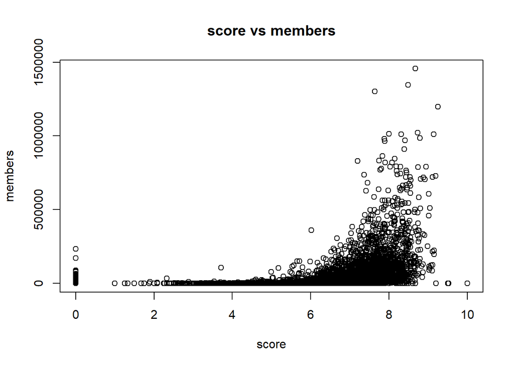

```r
plot(df$score, df$members, xlab=c('score'), ylab=c('members'), main=c('score vs members'))
```

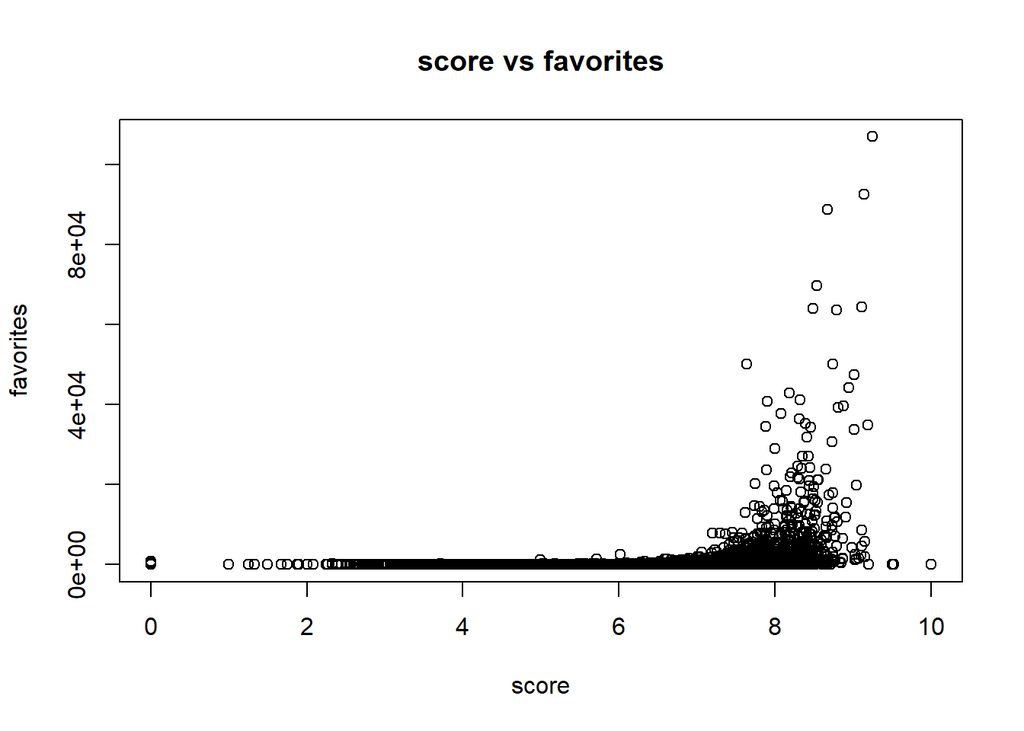

```r
plot(df$score, df$favorites, xlab=c('score'), ylab=('favorites'), main=c('score vs favorites'))
```

Y eso es todo por hoy :)

[figure not shown]